# CheckPoint2

Arthur Sena

05/11/2015

```r
  library(ggplot2, quietly = T, warn.conflicts = F)
  library(dplyr, quietly = T, warn.conflicts = F)
```

# Descrição dos Dados

Os nossos dados são referentes aos gols do campeonato brasileiro de 2013. Onde, no total, nós temos um conjunto com 973 observações cada uma com 7 colunas/variáveis. Uma pequena amostra dos dados pode ser visualizada logo abaixo:

```r
     gols<-read.csv("camp brasileiro 2013 - dados processados copy.csv")
     head(gols)
```

```
##   id_jogo        time_a        time_b tempo_gol      time_gol
## 1       1 Vasco da Gama    Portuguesa        47 Vasco da Gama
## 2       2       Vitória Internacional         2       Vitória
## 3       2       Vitória Internacional        11       Vitória
## 4       2       Vitória Internacional        29 Internacional
## 5       2       Vitória Internacional        63 Internacional
## 6       3   Corinthians      Botafogo        24      Botafogo
##   placar_time_a placar_time_b
## 1             1             0
## 2             1             0
## 3             2             0
## 4             2             1
## 5             2             2
## 6             0             1
```

Os dados acima apresentam uma columa de “tempo_gol”, na qual representa o minuto em que um determinado gol ocorreu naquele jogo. Para efeito de melhor visualização e entendimento dos dados, nós podemos criar um histograma com a frequência de gols em cada tempo do jogo.

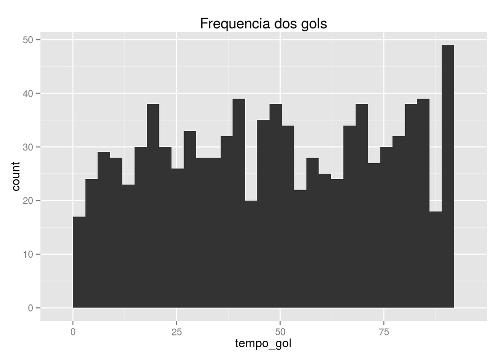

```r
        gols <- filter(gols,tempo_gol != "None")
        gols$tempo_gol <- as.numeric(gols$tempo_gol)

        tempo1 <- filter(gols,tempo_gol <= 45)
        tempo2 <- filter(gols,tempo_gol > 45)
        tempo2$tempo_gol <- tempo2$tempo_gol - 45

        qplot(data = gols, tempo_gol, geom = "histogram")+ggtitle("Frequencia dos gols")
```

# Análise dos Dados

Com os dados em mãos, nós podemos fazer algumas perguntas interessantes, como por exemplo: Existe diferença significativa entre o momento em que o gol acontece no 1o e 2o tempo das partidas, considerando o minuto do 1o ou 2o tempo em que ele acontece?

Para responder essa pergunta, nós precisamos dividir os gols entre os que ocorreram no primeiro tempo e os que ocorreram no segundo tempo do jogo. Feito isso, podemos aplicar um teste de hipótese no qual minhas hipóteses seriam:

**Hipótese Nula:** Não existe diferença significativa entre a média dos gols.  
**Hipótese Alternativa:** Existe uma diferença significativa entre a média dos gols.

```r
        gols<-read.csv("camp brasileiro 2013 - dados processados copy.csv")
        gols <- filter(gols,tempo_gol != "None")
        gols$tempo_gol <- as.numeric(gols$tempo_gol)

        tempo1 <- filter(gols,tempo_gol <= 45)
        tempo2 <- filter(gols,tempo_gol > 45)
        tempo2$tempo_gol <- tempo2$tempo_gol - 45

        t.test(tempo1$tempo_gol,tempo2$tempo_gol)
```

```
##
##  Welch Two Sample t-test
##
## data:  tempo1$tempo_gol and tempo2$tempo_gol
## t = -1.1699, df = 931.85, p-value = 0.2423
## alternative hypothesis: true difference in means is not equal to 0
## 95 percent confidence interval:
##  -2.7279333  0.6902483
## sample estimates:
## mean of x mean of y
##  23.59361  24.61245
```

Observando o valor do “p-value”, o qual se refere ao valor da probabilidade de refutar a hipótese nula. Se o “p-value” apresentar um valor menor que o alfa, onde nesse caso é 5%, nós podemos refutar a hiótese nula. Caso contrário, não podemos refutá-la. No nosso caso, podemos notar que o valor do “p-value” é maior que o alfa, ou seja, não podemos refutar a hipótese nula. Outra informação valiosa é o intervalo de confiança da diferença das médias, onde obtemos um intervalo entre [-2.7279333, 0.6902483]. Observando esse intervalo podemos perceber que o valor zero se encontra incluindo nele, ou seja, com 95% de confiança dizemos que não existe uma diferença significativa entre as médias dos gols nos dois tempos.

**Utilizando o “Wilcoxon test”** nós podemos refazer o experimento anterior utilizando as mesmas hipótese, mas usando a mediana como parâmetro.

```r
      wilcox.test(tempo1$tempo_gol,tempo2$tempo_gol)
```

```
##
##  Wilcoxon rank sum test with continuity correction
##
## data:  tempo1$tempo_gol and tempo2$tempo_gol
## W = 103880, p-value = 0.2089
## alternative hypothesis: true location shift is not equal to 0
```

Mais uma vez notamos que o valor do “p-value” é maior que 5% (alfa), ou seja, continuamos não podendo refutar a hipótese nula.

Após calcularmos os resultados dos testes de hipóteses com os Intervalos de Confiança podemos concluir que as duas técnicas se auto complementam, no sentido que sem o IC eu não consigo afirmar o tamanho da diferença das médias, caso exista tal diferença. Com o mesmo raciocinio, podemos dizer que sem o teste de hipóteses não temos o valor do p-value, ou seja, não tenho a probabilidade de rejeitar a hipótese nula.

Assim sendo, poderíamos concluir dizendo que as duas técnias permitem chegar na mesma conclusão, por exemplo, o gráfico abaixo representa o intervalo de confiança das médias dos gols no primeiro e segundo tempo. Observando tal gráfico, é facilmente notado que tais intervalos, praticamente, sobrepõem um ao outro.

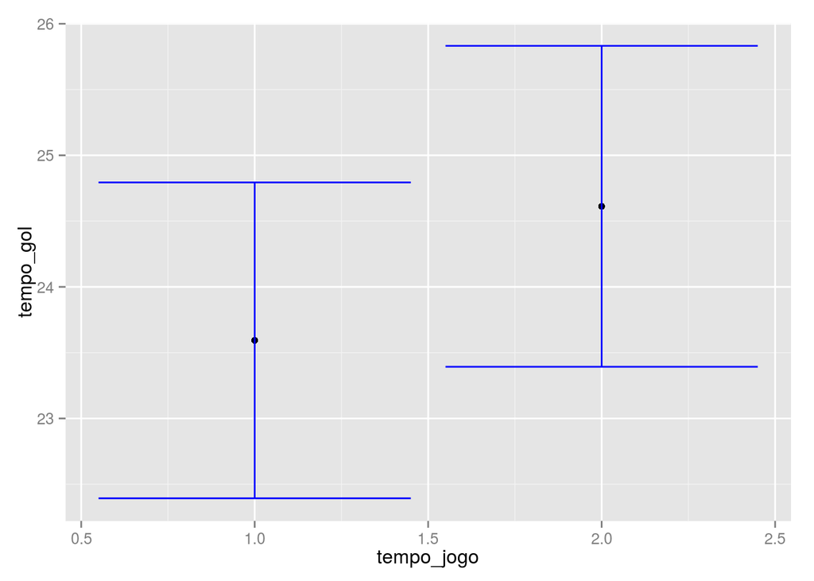

```r
        gols<-read.csv("camp brasileiro 2013 - dados processados copy.csv")
        gols <- filter(gols,tempo_gol != "None")
        gols$tempo_gol <- as.numeric(gols$tempo_gol)

        gols$tempo_jogo <- 0

         for (i in seq(1,nrow(gols))){
           if (gols[i,4] > 45){
             gols[i,8] <- 2
             gols[i,4] <- gols[i,4] - 45
           }
           else{
             gols[i,8] <- 1
           }
         }

        ggplot(gols, aes(x = tempo_jogo, y = tempo_gol)) +
          stat_summary(fun.y = mean, geom = "point") +
          stat_summary(fun.data = mean_cl_normal, geom = "errorbar", colour = "blue")
```